# Impact of Outliers on Measures of Location

Barbara Sánchez

2025-08-13

# 1. Introducción

El trabajo actual ha sido realizado con *fines de estudio*, para poder ver el impacto que tienen los outliers sobre la media, mediana y moda.

Este dataset incluye las calificaciones, tiempo de estudio y número de cursos de ciertos estudiantes.

- Número de variables: 3
- Número de observaciones: 100

Dataset tomado de https://www.kaggle.com/yasserh

Dataset: https://www.kaggle.com/datasets/yasserh/student-marks-dataset

# 2. Objetivos

- Calcular y representar gráficamente la media, mediana y moda
- Visualizar y comprender el impacto que tienen los outliers sobre la media, mediana y moda.

# 3. Configuración

Instalamos los paquetes y cargamos las librerías necesarias.

```r
# Install necessary packages and libraries

#install.packages("tidyverse")
#install.packages("ggplot2")
#install.packages("dplyr")
library(readr)
library(dplyr)
library(ggplot2)
```

# 4. Carga de datos

```r
# Read raw
df <- read_csv("data/raw/Student_Marks.csv")
```

# 5. Exploración inicial (EDA básico)

```r
head(df)
```

| number_courses | time_study | Marks |
| --- | --- | --- |
| 3 | 4.508 | 19.202 |
| 4 | 0.096 | 7.734 |
| 4 | 3.133 | 13.811 |
| 6 | 7.909 | 53.018 |
| 8 | 7.811 | 55.299 |
| 6 | 3.211 | 17.822 |

```r
# Internal structure of the df
glimpse(df)
```

```
Rows: 100
Columns: 3
$ number_courses <dbl> 3, 4, 4, 6, 8, 6, 3, 5, 4, 3, 3, 7, 7, 3, 3, 4, 5, 8, 6, 8, …
$ time_study     <dbl> 4.508, 0.096, 3.133, 7.909, 7.811, 3.211, 6.063, 3.413, 4.41…
$ Marks          <dbl> 19.202, 7.734, 13.811, 53.018, 55.299, 17.822, 29.889, 17.26…
```

```r
# Statistical summary
summary(df)
```

```
 number_courses   time_study        Marks
 Min.   :3.00   Min.   :0.096   Min.   : 5.609
 1st Qu.:4.00   1st Qu.:2.058   1st Qu.:12.633
 Median :5.00   Median :4.022   Median :20.059
 Mean   :5.29   Mean   :4.077   Mean   :24.418
 3rd Qu.:7.00   3rd Qu.:6.179   3rd Qu.:36.676
 Max.   :8.00   Max.   :7.957   Max.   :55.299
```

```r
# Test for NAs

anyNA(df)
```

```
[1] FALSE
```

```r
sum(is.na(df))
```

```
[1] 0
```

# 6. Medidas de localización

Las medidas de localización se han calculado respecto a la variable Marks.

## 6.1 Media

```r
# Calculate mean

media <- mean(df$Marks, na.rm = TRUE)

print(round(media,1))
```

```
[1] 24.4
```

## 6.2 Mediana

```r
# Calculate median
mediana <- median(df$Marks, na.rm = TRUE)
print(round(mediana, 1))
```

```
[1] 20.1
```

## 6.3 Moda

```r
# Calculate mode
# In a bimodal or multimodal situation, it only returns the lowest mode.

freq_table <- table(df$Marks)
moda <- min(as.numeric(names(freq_table)[freq_table == max(freq_table)]))
print(round(moda, 1))
```

```
[1] 5.6
```

## 6.4 Visualizamos la media, mediana y moda:

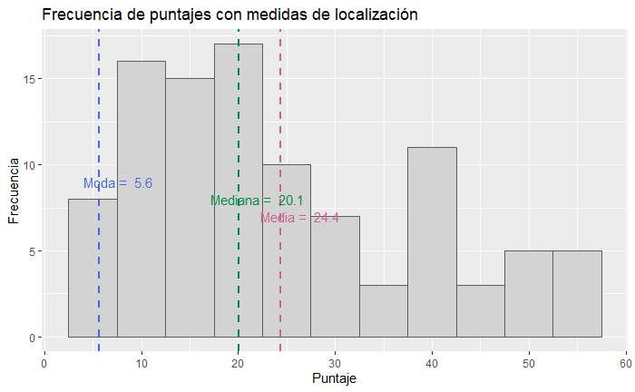

```r
ggplot(df, aes(x = Marks)) +
  geom_histogram(binwidth = 5, fill = "lightgray", color = "gray36") +
  # Mean
  geom_vline(aes(xintercept = media), color = "#CD6090", linetype = "dashed", size = 1) +
  annotate("text", x = media + 2, y = 7, label = paste("Media = ", round(media, 1)), color = "#CD6090") +
  # Median
  geom_vline(aes(xintercept = mediana), color = "#008B45", linetype = "dashed", size = 1) +
  annotate("text", x = mediana + 2, y = 8, label = paste("Mediana = ", round(mediana, 1)), color = "#008B45") +
  # Mode
  geom_vline(aes(xintercept = moda), color = "#4169E1", linetype = "dashed", size = 1) +
  annotate("text", x = moda + 2, y = 9, label = paste("Moda = ", round(moda, 1)), color = "#4169E1") +
  # Labels
  labs(title = "Frecuencia de puntajes con medidas de localización", x ="Puntaje", y ="Frecuencia")
```

# 7. Impacto de outliers en las medidas de localización

## 7.1 Dataset con outliers en Marks

```r
# Copy the df

df_outliers <- df

# Add outliers

df_outliers <- rbind(df_outliers, data.frame(
                                              number_courses = c(10, 12, 15),
                                              time_study = c(1, 2, 3),
                                              Marks = c(100, 99, 98)
)
)
```

## 7.2 Media

```r
# Calculate mean

media_out <- mean(df_outliers$Marks, na.rm = TRUE)

print(round(media_out, 1))
```

```
[1] 26.6
```

## 7.3 Mediana

```r
# Calculate median
mediana_out <- median(df_outliers$Marks, na.rm = TRUE)
print(round(mediana_out, 1))
```

```
[1] 20.4
```

## 7.4 Moda

```r
# Calculate mode
# In a bimodal or multimodal situation, it only returns the lowest mode.

freq_table_out <- table(df_outliers$Marks)
moda_out <- min(as.numeric(names(freq_table_out)[freq_table_out == max(freq_table_out)]))
print(round(moda_out, 1))
```

```
[1] 5.6
```

## 7.5 Visualizamos el impacto de los outliers sobre la media, mediana y moda :

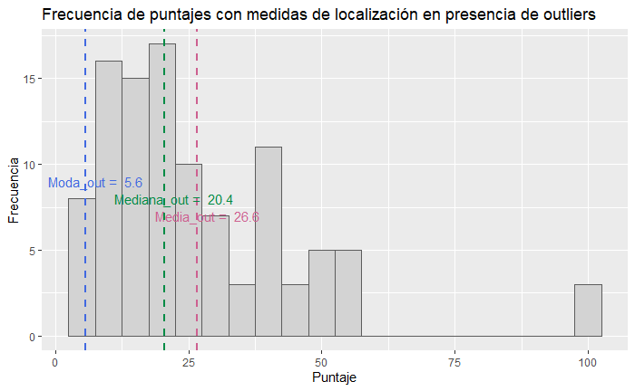

```r
ggplot(df_outliers, aes(x = Marks)) +
  geom_histogram(binwidth = 5, fill = "lightgray", color = "gray36") +
  # Mean
  geom_vline(aes(xintercept = media_out), color = "#CD6090", linetype = "dashed", size = 1) +
  annotate("text", x = media_out + 2, y = 7, label = paste("Media_out = ", round(media_out, 1)), color = "#CD6090") +
  # Median
  geom_vline(aes(xintercept = mediana_out), color = "#008B45", linetype = "dashed", size = 1) +
  annotate("text", x = mediana_out + 2, y = 8, label = paste("Mediana_out = ", round(mediana_out, 1)), color = "#008B45") +
  # Mode
  geom_vline(aes(xintercept = moda_out), color = "#4169E1", linetype = "dashed", size = 1) +
  annotate("text", x = moda_out + 2, y = 9, label = paste("Moda_out = ", round(moda_out, 1)), color = "#4169E1") +
  # Labels
  labs(title = "Frecuencia de puntajes con medidas de localización en presencia de outliers", x ="Puntaje", y ="Frecuencia")
```

# 8. Conclusiones:

- La media es la medida más afectada por la presencia de outliers, desplazándose considerablemente hacia el extremo (donde se encuentran estos outliers).
- La mediana presenta una afectación mínima por la presencia de outliers, lo cual podríamos interpretar como que es más resistente a valores extremos; por lo que es la medida más robusta ante outliers.
- La moda no se afecta por los outliers, ya que aparecen en menor cantidad que los valores con frecuencia máxima (modas).
- En análisis de datos reales, especialmente con presencia de outliers, la mediana y otras medidas robustas suelen proporcionar una descripción más representativa que la media.
- Este análisis evidencia la importancia de identificar y manejar los outliers antes de interpretar las medidas de tendencia central, especialmente cuando la media se utiliza como indicador principal en contextos educativos o de rendimiento académico.